# **Lab: Fairness and Ethical Considerations**

```
- Salissa Hernandez
- Juan Carlos Dominguez
- Leonardo Piedrahita
- Brice Danvide
```

**DATASET**: https://www.kaggle.com/datasets/kazanova/sentiment140/data

# **1. Dataset Overview**

### **1.1 Type of Bias Investigated**

This investigation focuses on **gender bias** in a sentiment analysis model using the **Sentiment140** dataset (source: https://www.kaggle.com/datasets/kazanova/sentiment140/data). Gender bias occurs when a machine learning model systematically assigns different sentiment scores to text based on gender-related attributes, such as gendered pronouns, names, or phrases commonly associated with men or women. This type of bias can lead to unfair treatment of certain groups, reinforcing harmful stereotypes or misrepresenting opinions based on implicit gender associations.

In the context of sentiment analysis, gender bias manifests when a model consistently predicts more negative sentiment for tweets containing female-associated words compared to those containing male-associated words, even when the overall meaning of the text remains neutral or positive. Such discrepancies can have real-world consequences, particularly in applications such as social media monitoring, customer feedback analysis, and brand reputation management, where sentiment analysis models are frequently deployed. If left unaddressed, biased sentiment classification can lead to skewed conclusions about public opinion, disproportionately impact certain demographics, and perpetuate existing social biases in automated decision-making systems.

To measure this bias, tweets will be categorized based on the presence of male- and female-associated names, pronouns, and gendered words using a predefined lexicon. Statistical tests such as a t-test or chi-square test will be employed to determine whether significant disparities exist in sentiment classification based on gender-related terms.

### **1.2 Pre-trained Model Utilized**

The model selected for this investigation is a pre-trained **BERT model** fine-tuned for sentiment analysis. BERT (Bidirectional Encoder Representations from Transformers) is a state-of-the-art language model that has been widely used for natural language processing tasks, including sentiment analysis. BERT has achieved state-of-the-art performance on a wide range of natural language processing (NLP) tasks due to its ability to capture complex linguistic patterns through deep bidirectional context modeling. However, despite its effectiveness, BERT is not immune to bias, as it is trained on large-scale text corpora that inherently reflect societal inequalities. Pretraining on vast datasets such as Wikipedia, BooksCorpus, and web text means that BERT has likely learned gendered language patterns that can influence its sentiment classification decisions.

Prior research has shown that models like BERT exhibit gender bias in word embeddings, associating male terms with power-related words and female terms with emotions. Fine-tuning BERT on the Sentiment140 dataset further exposes the model to potential bias present in real-world Twitter data. Since social media platforms often reflect social norms, stereotypes, and biased language, the model may learn and reinforce unintended biases from the dataset. By analyzing how BERT classifies tweets containing gendered words or pronouns, this study aims to assess whether its sentiment predictions differ systematically based on gender, thereby providing insights into potential fairness issues in NLP models.

### **1.3 Relevance of Investigation**

The presence of gender bias in sentiment analysis models has significant implications for both academia and industry. Sentiment analysis is widely used in various domains, including marketing, political analysis, mental health monitoring, and automated moderation systems. If these models exhibit gender bias, they can disproportionately amplify or diminish sentiment based on gendered language, leading to inaccurate assessments and potential harm to affected groups. For instance, biased sentiment classification in customer feedback analysis could result in skewed business decisions, while biased moderation systems on social media platforms could disproportionately flag or suppress certain viewpoints.

Furthermore, this investigation contributes to the growing field of fairness and bias mitigation in machine learning, particularly in NLP. Identifying and addressing gender bias in sentiment analysis is crucial for developing more equitable AI systems that do not reinforce societal disparities. By systematically evaluating the Sentiment140-trained BERT model’s performance across gender-related text features, this study highlights the broader challenges of bias in machine learning and explores potential mitigation strategies.

It is also important to consider potential confounders when measuring bias. Gendered language can vary by context, and certain words (e.g., "strong," "beautiful") may have different sentiment associations unrelated to bias. Additionally, sentiment scores may be influenced by cultural or linguistic variations within the dataset, which must be accounted for in the analysis.

To effectively analyze gender bias, this investigation will measure differences in sentiment classification across tweets that contain male- and female-associated names, pronouns, and gendered words. Statistical analyses, such as t-tests or chi-square tests, will be conducted to determine whether the model exhibits significant disparities in sentiment assignment. If bias is detected, various bias mitigation techniques—such as dataset balancing, counterfactual data augmentation, or adversarial debiasing—may be explored to assess their effectiveness in reducing bias.

This study underscores the importance of fairness in AI and aims to provide actionable insights for researchers and practitioners seeking to build more inclusive and unbiased sentiment analysis models.

# **2. Research Questions & Hypothesis**

### **2.1 Research Questions**

The primary research questions guiding this investigation are:

1. **Does the pre-trained BERT model exhibit gender bias in sentiment classification when applied to tweets containing gendered words/pronouns?**
2. **How do sentiment predictions for tweets that mention or are associated with women compare to those associated with men in terms of sentiment polarity (positive or negative)?**
3. **What methods can be used to mitigate any detected gender bias in sentiment classification, and how effective are these methods in improving fairness in sentiment predictions?**

### **2.2 Hypothesis**

The hypothesis for this research is that the pre-trained BERT model, when fine-tuned on the Sentiment140 dataset, will show systematic gender bias in its sentiment predictions. Specifically, it is expected that the model will more frequently classify tweets associated with women as having negative sentiment, while tweets associated with men will more often be classified as having positive sentiment. This hypothesis is based on the assumption that BERT’s training on large-scale data, including potentially biased text from sources like Wikipedia and web text, has led it to internalize societal gender biases, which it may apply to its sentiment analysis task.

### **2.3 Methods for Answering Research Questions**

To answer the research questions above, the following methods will be employed:

1. **Data Preparation and Preprocessing**:
   - **Dataset Selection**: The Sentiment140 dataset will be used, which contains 1.6 million tweets labeled with sentiment (positive or negative).
   - **Gendered Text Selection**: The dataset will be filtered to identify tweets containing gendered words or pronouns, including common names (e.g., "John," "Mary") and gender-specific pronouns (e.g., "he," "she").
   - **Classification Labels**: Tweets will be labeled based on the presence of gendered language to allow for comparison between male- and female-associated tweets.
2. **Transfer Learning Classification Task**:
   - **Fine-Tuning BERT**: The pre-trained BERT model will be fine-tuned on the Sentiment140 dataset to perform sentiment analysis. This model will be used as the baseline to investigate potential bias.
   - **Gender-Specific Sentiment Prediction**: The fine-tuned BERT model will then be tested on gendered subsets of the dataset. For example, the model will be tasked with classifying tweets containing male-associated names and pronouns separately from tweets with female-associated names and pronouns.
   - **Bias Measurement**: The model's predictions for male- and female-associated tweets will be compared statistically. Metrics such as **accuracy**, **precision**, **recall**, and **F1-score** will be used to assess sentiment classification performance for each gendered group. Additionally, **sentiment polarity distribution** (positive, negative, neutral) will be analyzed to detect discrepancies between the two groups.
3. **Bias Mitigation Exploration**:
   - **Counterfactual Data Augmentation**: To reduce gender bias, the dataset may be augmented with counterfactual data, where names and pronouns are swapped between male and female-associated tweets, while preserving the original tweet content. The fine-tuned model will be retrained on this augmented data, and the results will be compared to see if bias is mitigated.
   - **Dataset Balancing**: If gendered words are not evenly distributed across positive and negative sentiment labels, techniques such as oversampling or undersampling may be employed to balance the dataset and test if this improves fairness.
   - **Adversarial Debiasing**: As an alternative approach, adversarial debiasing techniques may be implemented to reduce gendered bias by introducing a secondary model that penalizes the primary model for predicting sentiment based on gendered patterns.
4. **Statistical Analysis**:
   - **Statistical Testing**: To evaluate the presence of gender bias, statistical tests such as the **Chi-square test** for independence or **t-tests** will be used to compare the sentiment prediction rates for male- and female-associated tweets. Significant differences would indicate bias in the model’s predictions.
   - **Fairness Metrics**: Measures of fairness, such as **Demographic Parity** and **Equal Opportunity**, will be used to evaluate whether the model’s predictions are equally accurate for different gendered groups.

### **2.4 Transfer Learning Task & Bias Uncovering**

The transfer learning classification task, which involves fine-tuning BERT on sentiment analysis and applying it to gendered subsets of the dataset, will help uncover gender bias by comparing the model's performance on tweets that contain male-associated and female-associated words. This task will reveal whether the model treats tweets with different gendered associations differently, which could be an indication of bias. By testing on both balanced and augmented datasets, the investigation will also assess how well bias mitigation techniques can reduce or eliminate gender disparities in sentiment predictions.

This transfer learning task is particularly useful for uncovering biases because it allows the model to learn from a domain-specific dataset (Sentiment140) while leveraging knowledge from a pre-trained model (BERT) that has been trained on vast amounts of general language data. Through this approach, any gendered bias inherent in the pre-trained model can be identified, measured, and potentially corrected, contributing to a deeper understanding of how gender bias affects sentiment analysis in NLP models.

# **3. Bias Mitigation Method and Evaluation**

### **3.2 Comparison of Bias in the Original and Mitigated Model**

To evaluate the effectiveness of CDA, two versions of the BERT model will be fine-tuned on the Sentiment140 dataset:

Once trained, both models will be evaluated on a test set containing gendered words to assess differences in sentiment predictions.

### **3.3 Measuring the Difference Between Model Outputs**

Additionally, sentiment score distributions before and after bias mitigation will be analyzed using **statistical hypothesis testing**.

### **3.4 Statistical Test for Bias Evaluation**

To evaluate differences in sentiment predictions before and after bias mitigation, a Chi-Square Test will be conducted:

- **Chi-Square Test** – This statistical test will be used to determine whether there is a significant difference in categorical data distributions. Specifically, it will compare the frequency of positive sentiment predictions for male- and female-associated tweets before and after bias mitigation. The chi-square test is appropriate for assessing whether any observed differences in sentiment predictions are statistically significant or if they occurred by chance.

By performing this test, the goal is to determine whether the bias mitigation strategy effectively reduces disparities in sentiment classification between gender-associated texts.

### **3.5 Limitations of the Approach**

Despite these limitations, CDA provides a straightforward and interpretable method for reducing gender bias in sentiment analysis models. The findings from this study will contribute to ongoing research in fairness-aware machine learning and help improve the ethical deployment of NLP systems.

# **4. Data Preparation**

### **4.1 Dataset Preprocessing**

```python
# Modules & Libraries
import pandas as pd
import numpy as np
import matplotlib.pyplot as plt
import seaborn as sns
import re
import emoji
import contractions
from wordcloud import WordCloud, STOPWORDS

import torch
from transformers import BertTokenizer, BertForSequenceClassification, get_scheduler
from torch.utils.data import DataLoader, TensorDataset
from sklearn.model_selection import train_test_split
import torch.nn.functional as F
import torch.nn as nn

from scipy.stats import ttest_ind
from transformers import BertTokenizer, TFBertForSequenceClassification, Trainer, TrainingArguments
from sklearn.model_selection import train_test_split
from sklearn.metrics import accuracy_score, f1_score, classification_report
from scipy.stats import chi2_contingency
```

```python
# Reading the dataset
df_raw = pd.read_csv(r"C:\Users\Juan Dominguez\Desktop\sentiment140.csv", encoding="ISO-8859-1")
df_raw.columns = ["sentiment", "id", "date", "query", "username", "text"]

# Display the first few rows
df_raw.head()
```

|  | sentiment | id | date | query | username | text |
| --- | --- | --- | --- | --- | --- | --- |
| 0 | 0 | 1467810672 | Mon Apr 06 22:19:49 PDT 2009 | NO_QUERY | scotthamilton | is upset that he can't update his Facebook by ... |
| 1 | 0 | 1467810917 | Mon Apr 06 22:19:53 PDT 2009 | NO_QUERY | mattycus | @Kenichan I dived many times for the ball. Man... |
| 2 | 0 | 1467811184 | Mon Apr 06 22:19:57 PDT 2009 | NO_QUERY | ElleCTF | my whole body feels itchy and like its on fire |
| 3 | 0 | 1467811193 | Mon Apr 06 22:19:57 PDT 2009 | NO_QUERY | Karoli | @nationwideclass no, it's not behaving at all.... |
| 4 | 0 | 1467811372 | Mon Apr 06 22:20:00 PDT 2009 | NO_QUERY | joy_wolf | @Kwesidei not the whole crew |

```python
df_raw.info()
```

```
<class 'pandas.core.frame.DataFrame'>
RangeIndex: 1599999 entries, 0 to 1599998
Data columns (total 6 columns):
 #   Column     Non-Null Count    Dtype
---  ------     --------------    -----
 0   sentiment  1599999 non-null  int64
 1   id         1599999 non-null  int64
 2   date       1599999 non-null  object
 3   query      1599999 non-null  object
 4   username   1599999 non-null  object
 5   text       1599999 non-null  object
dtypes: int64(2), object(4)
memory usage: 73.2+ MB
```

```python
# We are only training on "text" so we can drop the following columns
df_raw.drop(["id", "date", "query", "username"], axis=1, inplace=True)
df_raw.head()
```

|  | sentiment | text |
| --- | --- | --- |
| 0 | 0 | is upset that he can't update his Facebook by ... |
| 1 | 0 | @Kenichan I dived many times for the ball. Man... |
| 2 | 0 | my whole body feels itchy and like its on fire |
| 3 | 0 | @nationwideclass no, it's not behaving at all.... |
| 4 | 0 | @Kwesidei not the whole crew |

```python
# Mapping "sentiment" values: 0 = Negative, 1 = Positive
df_raw["sentiment"] = df_raw["sentiment"].map({0: 0, 4: 1})
```

```python
# check shape prior to cleanning
original_shape = df_raw.shape
print("Original Shape:", original_shape)

# check missing values
missing_values = df_raw["sentiment"].isnull().sum()
print("Number of missing values:", missing_values)
```

```
Original Shape: (1599999, 2)
Number of missing values: 0
```

```python
# check dupllicates
num_duplicates = df_raw.duplicated().sum()
print("Number of duplicate rows:", num_duplicates)
```

```
Number of duplicate rows: 16309
```

```python
# remove duplicates
df_raw.drop_duplicates(inplace=True)
new_shape = df_raw.shape
print("Dataset shape after removing duplicates:", new_shape)
```

```
Dataset shape after removing duplicates: (1583690, 2)
```

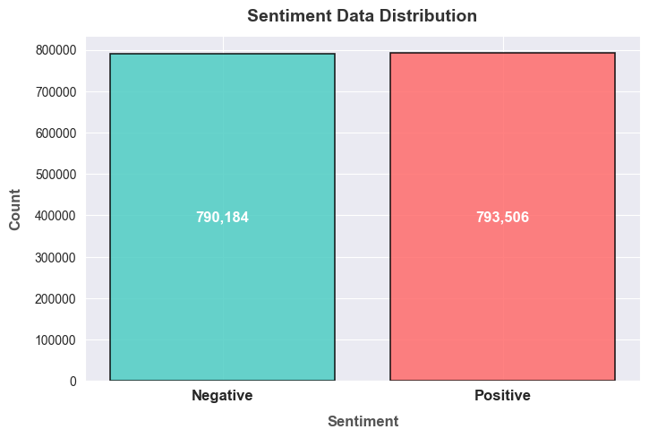

```python
# Displaying the sentiment values
sentiment = df_raw.sentiment.value_counts()

colors = ["#FF6B6B", "#4ECDC4"]  # Soft red for negative, teal for positive
sns.set_style("darkgrid")

# Creates figure
plt.figure(figsize=(8, 5))
bars = plt.bar(sentiment.index, sentiment.values, color=colors, alpha=0.85, edgecolor="black", linewidth=1.2)
plt.xticks(ticks=[0, 1], labels=["Negative", "Positive"], fontsize=12, fontweight="bold")
plt.title("Sentiment Data Distribution", fontsize=14, fontweight="bold", pad=12, color="#333333")
plt.xlabel("Sentiment", fontsize=12, labelpad=10, fontweight="bold", color="#555555")
plt.ylabel("Count", fontsize=12, labelpad=10, fontweight="bold", color="#555555")

# Adds value labels inside bars
for bar in bars:
    plt.text(bar.get_x() + bar.get_width()/2,  # Center horizontally
             bar.get_height() * 0.5,  # Position in the middle of the bar
             f"{int(bar.get_height()):,}",  # Format number with commas
             ha="center", va="center",  # Align text in center
             fontsize=12, fontweight="bold", color="white")  # White text for contrast

plt.show()
```

### **4.2 Text Preprocessing**

```python
# Cleaning the tweets
def clean_tweet(tweet):
    # Convert emojis to text
    tweet = emoji.demojize(tweet, delimiters=(" ", " "))

    # Expands contractions (e.g., "don't" -> "do not")
    tweet = contractions.fix(tweet)

    # Removes URLs
    tweet = re.sub(r'http\S+|www\S+|https\S+', '', tweet, flags=re.MULTILINE)

    # Remove mentions
    tweet = re.sub(r'@\w+', '', tweet)

    # Fix hashtags, keep words seperate
    tweet = re.sub(r'#(\w+)', r'\1 ', tweet)

    # Removes special characters except apostrophes and hyphens
    tweet = re.sub(r"[^a-zA-Z0-9'’\-!?.,]", ' ', tweet)

    # Removes extra spaces and leading/trailing whitespace
    tweet = re.sub(r'\s+', ' ', tweet).strip()

    # Replace numbers with a token
    tweet = re.sub(r'\d+', ' <NUM> ', tweet)

    # Converts to lowercase for consistency
    tweet = tweet.lower()

    return tweet

# Applies cleaning function
df_raw['cleaned_text'] = df_raw['text'].apply(clean_tweet)

# Double check missing values/empty rows AFTER cleaning
print("Missing values in 'cleaned_text':", df_raw['cleaned_text'].isnull().sum())
print("Empty rows in 'cleaned_text':", (df_raw['cleaned_text'].str.strip() == "").sum())

# Removes rows with empty text after cleaning
df_raw = df_raw[df_raw['cleaned_text'].str.strip() != '']
print("Empty rows in 'cleaned_text':", (df_raw['cleaned_text'].str.strip() == "").sum())

df_raw.head()
```

```
Missing values in 'cleaned_text': 0
Empty rows in 'cleaned_text': 2773
Empty rows in 'cleaned_text': 0
```

|  | sentiment | text | cleaned_text |
| --- | --- | --- | --- |
| 0 | 0 | is upset that he can't update his Facebook by ... | is upset that he cannot update his facebook by... |
| 1 | 0 | @Kenichan I dived many times for the ball. Man... | i dived many times for the ball. managed to sa... |
| 2 | 0 | my whole body feels itchy and like its on fire | my whole body feels itchy and like its on fire |
| 3 | 0 | @nationwideclass no, it's not behaving at all.... | no, it is not behaving at all. i am mad. why a... |
| 4 | 0 | @Kwesidei not the whole crew | not the whole crew |

```python
df_raw = df_raw[['sentiment', 'cleaned_text']]
df_raw.info()
```

```
<class 'pandas.core.frame.DataFrame'>
Index: 1580917 entries, 0 to 1599998
Data columns (total 2 columns):
 #   Column        Non-Null Count    Dtype
---  ------        --------------    -----
 0   sentiment     1580917 non-null  int64
 1   cleaned_text  1580917 non-null  object
dtypes: int64(1), object(1)
memory usage: 36.2+ MB
```

[figure not shown]

```python
# Word cloud for each sentiment
# Separate text based on sentiment
positive_text = " ".join(df_raw[df_raw["sentiment"] == 1]["cleaned_text"])
negative_text = " ".join(df_raw[df_raw["sentiment"] == 0]["cleaned_text"])

# define stopwords
stopwords = set(STOPWORDS)

# Generate word clouds
wordcloud_positive = WordCloud(width=800, height=400, background_color="white", colormap="Blues").generate(positive_text)
wordcloud_negative = WordCloud(width=800, height=400, background_color="black", colormap="Reds").generate(negative_text)

# Plot the word clouds
fig, ax = plt.subplots(1, 2, figsize=(14, 6))

ax[0].imshow(wordcloud_positive, interpolation="bilinear")
ax[0].set_title("Positive Sentiment", fontsize=14)
ax[0].axis("off")

ax[1].imshow(wordcloud_negative, interpolation="bilinear")
ax[1].set_title("Negative Sentiment", fontsize=14)
ax[1].axis("off")

plt.tight_layout()
plt.show()
```

```python
# Processed Dataframe
df_processed = df_raw.copy()
df_processed.head()
```

|  | sentiment | cleaned_text |
| --- | --- | --- |
| 0 | 0 | is upset that he cannot update his facebook by... |
| 1 | 0 | i dived many times for the ball. managed to sa... |
| 2 | 0 | my whole body feels itchy and like its on fire |
| 3 | 0 | no, it is not behaving at all. i am mad. why a... |
| 4 | 0 | not the whole crew |

```python
df_processed.info()
```

```
<class 'pandas.core.frame.DataFrame'>
Index: 1580917 entries, 0 to 1599998
Data columns (total 2 columns):
 #   Column        Non-Null Count    Dtype
---  ------        --------------    -----
 0   sentiment     1580917 non-null  int64
 1   cleaned_text  1580917 non-null  object
dtypes: int64(1), object(1)
memory usage: 36.2+ MB
```

# **5. Analysis & Model Training**

### **5.1 Data Splitting & Tokenization**

```python
# Step 1: Load and Prepare Data
positive_samples = df_processed[df_processed['sentiment'] == 1].sample(frac=0.01, random_state=42)
negative_samples = df_processed[df_processed['sentiment'] == 0].sample(frac=0.01, random_state=42)

df_subset = pd.concat([positive_samples, negative_samples]).sample(frac=1, random_state=42).reset_index(drop=True)

# Check Dataset Size After Sampling
print("Total samples after downsampling:", len(df_subset))

# ensure no empty tweets
df_subset = df_subset[df_subset['cleaned_text'].str.strip() != '']

X_subset = df_subset['cleaned_text'].tolist()
y_subset = df_subset['sentiment'].tolist()

# train test split
X_train_subset, X_test_subset, y_train_subset, y_test_subset = train_test_split(X_subset, y_subset, test_size=0.2, random_state=42)

# Step 2: Tokenization
tokenizer = BertTokenizer.from_pretrained('bert-base-uncased')

train_encodings = tokenizer(X_train_subset, padding=True, truncation=True, return_tensors='pt', max_length=128)
test_encodings = tokenizer(X_test_subset, padding=True, truncation=True, return_tensors='pt', max_length=128)

# Convert labels to tensor
train_labels = torch.tensor(y_train_subset, dtype=torch.long)
test_labels = torch.tensor(y_test_subset, dtype=torch.long)

# Detect GPU
device = torch.device('cuda' if torch.cuda.is_available() else 'cpu')

# Move input tensors to GPU
train_data = TensorDataset(train_encodings['input_ids'].to(device),
                           train_encodings['attention_mask'].to(device),
                           train_labels.to(device))

test_data = TensorDataset(test_encodings['input_ids'].to(device),
                          test_encodings['attention_mask'].to(device),
                          test_labels.to(device))

train_loader = DataLoader(train_data, batch_size=32, shuffle=True)
test_loader = DataLoader(test_data, batch_size=32)


print("Data prep done!")
```

```
Total samples after downsampling: 15809
Data prep done!
```

### Step 1 - Load and Prepare Data

This section of the code involves loading, processing, and preparing the dataset for training a machine learning model, specifically a BERT model for sentiment analysis. The following steps describe how the data is prepared for input into the model:

#### 1. **Load Positive and Negative Samples (Downsampling)**

```
positive_samples = df_processed[df_processed['sentiment'] == 1].sample(frac=0.01, random_state=42)
negative_samples = df_processed[df_processed['sentiment'] == 0].sample(frac=0.01, random_state=42)
```

- **Objective**: The dataset is balanced by sampling a smaller proportion of both positive and negative sentiment samples.
- `df_processed`: This is the preprocessed dataset containing sentiment-labeled text data. The `sentiment` column labels positive sentiment as `1` and negative sentiment as `0`.
- `df_processed['sentiment'] == 1`: Filters the dataset for rows with positive sentiment (1).
- `.sample(frac=0.01, random_state=42)`: Samples 1% of the positive and negative samples randomly. The `random_state=42` ensures that the same samples are chosen each time the code is run.
- `positive_samples` and `negative_samples`: These contain the 1% samples for positive and negative sentiments, respectively.

#### 2. **Concatenate Positive and Negative Samples**

```
df_subset = pd.concat([positive_samples, negative_samples]).sample(frac=1, random_state=42).reset_index(drop=True)
```

- **Objective**: After downsampling both positive and negative sentiment samples, the two datasets are concatenated and shuffled to ensure random order.
- `pd.concat([positive_samples, negative_samples])`: Combines the two sampled datasets into one.
- `.sample(frac=1, random_state=42)`: Shuffles the concatenated dataset. The `frac=1` argument means the entire dataset is shuffled.
- `.reset_index(drop=True)`: Resets the index of the shuffled dataset to ensure a clean, sequential index.

#### 3. **Check Dataset Size After Sampling**

```
print("Total samples after downsampling:", len(df_subset))
```

- **Objective**: Prints the number of samples in the dataset after downsampling. This step confirms that the data has been correctly prepared.

#### 4. **Remove Empty Tweets**

```
df_subset = df_subset[df_subset['cleaned_text'].str.strip() != '']
```

- **Objective**: Removes any rows where the `cleaned_text` column is empty or consists only of whitespace.
- `df_subset['cleaned_text'].str.strip() != ''`: This condition filters out rows where the `cleaned_text` is an empty string or made up of spaces only, ensuring the model is trained only on meaningful data.

#### 5. **Separate Features (X) and Labels (y)**

```
X_subset = df_subset['cleaned_text'].tolist()
y_subset = df_subset['sentiment'].tolist()
```

- **Objective**: Splits the data into input features (`X`) and output labels (`y`).
- `X_subset`: Contains the cleaned text data (the feature to be used for training).
- `y_subset`: Contains the sentiment labels (target values, either 0 or 1).

#### 6. **Train-Test Split**

```
X_train_subset, X_test_subset, y_train_subset, y_test_subset = train_test_split(X_subset, y_subset, test_size=0.2, random_state=42)
```

- **Objective**: Divides the dataset into training and testing sets.
- `train_test_split`: This function splits the data into training (80%) and testing (20%) sets. `test_size=0.2` specifies that 20% of the data will be used for testing, while the remaining 80% will be used for training.
- `X_train_subset` and `X_test_subset`: These are the text data used for training and testing, respectively.
- `y_train_subset` and `y_test_subset`: These are the sentiment labels for the training and testing sets.

### Step 2: Tokenization

#### 7. **Tokenization**

```
tokenizer = BertTokenizer.from_pretrained('bert-base-uncased')

train_encodings = tokenizer(X_train_subset, padding=True, truncation=True, return_tensors='pt', max_length=128)
test_encodings = tokenizer(X_test_subset, padding=True, truncation=True, return_tensors='pt', max_length=128)
```

- **Objective**: Converts the text data into a format that can be understood by BERT.
- `BertTokenizer.from_pretrained('bert-base-uncased')`: Loads the pre-trained BERT tokenizer (`bert-base-uncased`), which is specifically designed for lowercase English text.
- `train_encodings` and `test_encodings`: These contain the tokenized versions of the training and testing text data. The tokenizer applies padding to ensure all sequences are the same length and truncates longer sequences to a maximum length of 128 tokens. `return_tensors='pt'` ensures that the output is in PyTorch tensor format.

#### 8. **Convert Labels to Tensors**

```
train_labels = torch.tensor(y_train_subset, dtype=torch.long)
test_labels = torch.tensor(y_test_subset, dtype=torch.long)
```

- **Objective**: Converts the sentiment labels into PyTorch tensors.
- `torch.tensor`: This function converts the sentiment labels into tensors, which are required for training in PyTorch. The data type is set to `torch.long`, as the labels are integers.

#### 9. **Detect GPU and Move Tensors to GPU**

```
device = torch.device('cuda' if torch.cuda.is_available() else 'cpu')

train_data = TensorDataset(train_encodings['input_ids'].to(device),
                           train_encodings['attention_mask'].to(device),
                           train_labels.to(device))

test_data = TensorDataset(test_encodings['input_ids'].to(device),
                          test_encodings['attention_mask'].to(device),
                          test_labels.to(device))
```

- **Objective**: Detects whether a GPU is available and moves the data to the appropriate device (GPU or CPU).
- `torch.device('cuda' if torch.cuda.is_available() else 'cpu')`: This checks if a CUDA-compatible GPU is available. If yes, it assigns the device as `cuda`; otherwise, it defaults to `cpu`.
- `TensorDataset`: This creates a dataset that contains the tokenized input data (`input_ids`, `attention_mask`) and labels. The `.to(device)` method moves the data to the selected device (GPU or CPU).

#### 10. **Create DataLoaders**

```
train_loader = DataLoader(train_data, batch_size=32, shuffle=True)
test_loader = DataLoader(test_data, batch_size=32)
```

- **Objective**: Creates `DataLoader` objects for the training and testing sets, allowing the data to be processed in mini-batches.
- `batch_size=32`: Specifies that each batch will contain 32 samples.
- `shuffle=True`: This shuffles the training data before each epoch, which helps prevent the model from learning the order of the data.
- The test `DataLoader` does not shuffle the data because the goal is to evaluate the model on the original test set.

#### 11. **Confirm Data Preparation**

```
print("Data prep done!")
```

- **Objective**: Prints a confirmation message to indicate that the data preparation steps have been completed.

This section prepares the dataset for training by balancing the classes, cleaning up empty text, tokenizing the text data, splitting the data into training and testing sets, and ensuring that everything is ready for input into the model.

### **5.2 Optimizer**

```python
# Step 3: Load Model and Define Optimizer
device = torch.device('cuda' if torch.cuda.is_available() else 'cpu')

# load model
model = BertForSequenceClassification.from_pretrained('bert-base-uncased', num_labels=2)
model.to(device)

# init classifier weights
model.classifier.weight.data.normal_(mean=0.0, std=0.02)
model.classifier.bias.data.zero_()

# define optimizer
optimizer = torch.optim.AdamW(model.parameters(), lr=5e-5, weight_decay=0.01)

# define learning rate scheduler
num_training_steps = len(train_loader) * 3
lr_scheduler = get_scheduler("linear", optimizer=optimizer, num_warmup_steps=0,
                             num_training_steps=num_training_steps)

# Class Weights for Bias Mitigation
epsilon = 1e-6  # To prevent division by zero
class_counts = df_subset['sentiment'].value_counts().to_dict()
class_weights = torch.tensor([1.0 / (class_counts.get(0, epsilon)),
                              1.0 / (class_counts.get(1, epsilon))], dtype=torch.float32).to(device)

# normalize weights to balance the class distribution more effectively
class_weights /= class_weights.min()

# define weighted loss function (bias mitigation)
loss_fn = nn.CrossEntropyLoss(weight=class_weights)

print(f"Class weights (Negative, Positive): {class_weights.cpu().numpy()}")
```

```
Some weights of BertForSequenceClassification were not initialized from the model checkpoint at bert-base-uncased and are newly initialized: ['classifier.bias', 'classifier.weight']
You should probably TRAIN this model on a down-stream task to be able to use it for predictions and inference.
```

```
Class weights (Negative, Positive): [1.0044377 1.       ]
```

### Step 3 - Loading Model and Defining Optimizer

This section of the code involves loading the pre-trained BERT model, setting up the optimizer, defining a learning rate scheduler, and applying class weights to mitigate any bias in the dataset. The following steps describe how the model is prepared for training:

#### 1. **Detect GPU and Set Device**

```
device = torch.device('cuda' if torch.cuda.is_available() else 'cpu')
```

- **Objective**: This checks if a CUDA-compatible GPU is available for faster computation. If a GPU is available, the model will be moved to the GPU; otherwise, it will run on the CPU.
- `torch.device('cuda' if torch.cuda.is_available() else 'cpu')`: Returns a device object representing the available hardware (either GPU or CPU) for model training.

#### 2. **Load Pre-Trained BERT Model**

```
model = BertForSequenceClassification.from_pretrained('bert-base-uncased', num_labels=2)
model.to(device)
```

- **Objective**: Loads a pre-trained BERT model for sequence classification, which is tailored for tasks like sentiment analysis.
- `BertForSequenceClassification.from_pretrained('bert-base-uncased', num_labels=2)`: This loads the `bert-base-uncased` model, a version of BERT that has been pre-trained on a large corpus of text and is "uncased" (i.e., does not distinguish between uppercase and lowercase). The model is specifically configured for binary classification, as specified by `num_labels=2`.
- `model.to(device)`: Moves the model to the selected device (GPU or CPU) to ensure efficient computation.

#### 3. **Initialize Classifier Weights**

```
model.classifier.weight.data.normal_(mean=0.0, std=0.02)
model.classifier.bias.data.zero_()
```

- **Objective**: Initializes the weights of the classification layer. These weights are typically initialized randomly, but the code specifies a normal distribution for the weights and zeros for the biases.
- `model.classifier.weight.data.normal_(mean=0.0, std=0.02)`: Initializes the classifier weights with a normal distribution that has a mean of 0 and a standard deviation of 0.02. This is a standard method for initializing weights in neural networks.
- `model.classifier.bias.data.zero_()`: Sets the bias values of the classifier layer to zero, which is common practice in model initialization.

#### 4. **Define Optimizer**

```
optimizer = torch.optim.AdamW(model.parameters(), lr=5e-5, weight_decay=0.01)
```

- **Objective**: Sets up the optimizer, which is responsible for updating the model’s weights during training.
- `torch.optim.AdamW(model.parameters(), lr=5e-5, weight_decay=0.01)`: Uses the AdamW optimizer, a variation of the Adam optimizer that includes weight decay to prevent overfitting. `lr=5e-5` specifies the learning rate, and `weight_decay=0.01` applies regularization to the model parameters to reduce overfitting.

#### 5. **Define Learning Rate Scheduler**

```
num_training_steps = len(train_loader) * 3
lr_scheduler = get_scheduler("linear", optimizer=optimizer, num_warmup_steps=0,
                             num_training_steps=num_training_steps)
```

- **Objective**: Defines a learning rate scheduler, which adjusts the learning rate during training to improve convergence.
- `len(train_loader) * 3`: Calculates the total number of training steps, assuming the training will run for 3 epochs.
- `get_scheduler("linear", optimizer=optimizer, num_warmup_steps=0, num_training_steps=num_training_steps)`: Sets up a linear learning rate scheduler. During training, the learning rate will decrease linearly from the initial value to 0, after a specified number of warmup steps (set to 0 here). This is useful for fine-tuning BERT to avoid large updates to the model’s parameters early in training.

#### 6. **Class Weights for Bias Mitigation**

```
epsilon = 1e-6  # To prevent division by zero
class_counts = df_subset['sentiment'].value_counts().to_dict()
class_weights = torch.tensor([1.0 / (class_counts.get(0, epsilon)),
                              1.0 / (class_counts.get(1, epsilon))], dtype=torch.float32).to(device)
```

- **Objective**: This step calculates class weights for each sentiment class (positive and negative) to address any class imbalance.
- `class_counts = df_subset['sentiment'].value_counts().to_dict()`: This counts the occurrences of each sentiment class (0 for negative, 1 for positive) in the dataset and stores the counts in a dictionary.
- `class_weights`: The weight for each class is calculated by taking the reciprocal of the class counts. This ensures that the model gives more importance to underrepresented classes during training. `epsilon=1e-6` is used to prevent division by zero in case a class has no samples.

#### 7. **Normalize Class Weights**

```
class_weights /= class_weights.min()
```

- **Objective**: Normalizes the class weights to ensure that the smallest weight is 1, making the weights more balanced and effective.
- `class_weights /= class_weights.min()`: This divides all class weights by the smallest weight to normalize the weights. This ensures that the class weights are proportional, and helps mitigate bias during model training.

#### 8. **Define Weighted Loss Function**

```
loss_fn = nn.CrossEntropyLoss(weight=class_weights)
```

- **Objective**: Defines the loss function used to train the model, specifically a cross-entropy loss that accounts for class imbalance using the computed class weights.
- `nn.CrossEntropyLoss(weight=class_weights)`: This loss function is suitable for multi-class classification tasks and takes into account the weights for each class. By using the `class_weights`, it ensures that the model penalizes mistakes on underrepresented classes more than mistakes on the majority class.

#### 9. **Print Class Weights**

```
print(f"Class weights (Negative, Positive): {class_weights.cpu().numpy()}")
```

- **Objective**: Prints the calculated class weights to verify that they have been computed correctly.
- `class_weights.cpu().numpy()`: This moves the class weights from the GPU (if applicable) to the CPU and converts them to a NumPy array for easy printing.

### **5.3 Training Loop**

```python
# Step 4: Training Loop
model.train()

for epoch in range(3):
    total_loss = 0
    total_correct = 0
    total_samples = 0

    for batch in train_loader:
        input_ids, attention_mask, labels = [b.to(device) for b in batch]

        # forward pass
        optimizer.zero_grad()
        outputs = model(input_ids=input_ids, attention_mask=attention_mask, labels=labels)
        loss = loss_fn(outputs.logits, labels)  # Uses the weighted loss function
        total_loss += loss.item()

        # backpropagation
        loss.backward()
        optimizer.step()
        lr_scheduler.step()

        # computes training accuracy
        logits = outputs.logits
        predictions = torch.argmax(logits, dim=-1)
        total_correct += (predictions == labels).sum().item()
        total_samples += labels.size(0)

    train_acc = total_correct / total_samples
    avg_loss = total_loss / len(train_loader)

    print(f"Epoch {epoch+1}: Loss = {avg_loss:.4f}, Accuracy = {train_acc:.4f}")
```

```
Epoch 1: Loss = 0.4658, Accuracy = 0.7781
Epoch 2: Loss = 0.2639, Accuracy = 0.8948
Epoch 3: Loss = 0.0976, Accuracy = 0.9669
```

### Step 4 - Training Loop

This section implements the training loop for the BERT model. The model is trained over three epochs, and during each epoch, the loss and accuracy are calculated and displayed. The following steps outline how the training process works:

#### 1. **Set Model to Training Mode**

```
model.train()
```

- **Objective**: This line sets the model to training mode, which ensures that certain layers, like dropout and batch normalization, behave appropriately during training. It is essential to call `model.train()` before starting the training process to activate these layers.

#### 2. **Training Loop for Epochs**

```
for epoch in range(3):
    total_loss = 0
    total_correct = 0
    total_samples = 0
```

- **Objective**: The code starts a loop to run the training process for 3 epochs. The variables `total_loss`, `total_correct`, and `total_samples` are initialized to track the cumulative loss, the number of correct predictions, and the total number of samples processed during each epoch, respectively.
- `for epoch in range(3)`: Runs the loop for 3 iterations (epochs).

#### 3. **Iterate Over Batches in the Training Data**

```
for batch in train_loader:
    input_ids, attention_mask, labels = [b.to(device) for b in batch]
```

- **Objective**: The code then iterates over the training data in batches. For each batch, the input text is tokenized and moved to the specified device (GPU or CPU), and the corresponding labels (sentiment classes) are extracted.
- `input_ids, attention_mask, labels`: These are the components of the tokenized input text. `input_ids` are the tokenized text, `attention_mask` indicates which tokens are padding, and `labels` are the sentiment labels.

#### 4. **Forward Pass**

```
optimizer.zero_grad()
outputs = model(input_ids=input_ids, attention_mask=attention_mask, labels=labels)
loss = loss_fn(outputs.logits, labels)  # Use the weighted loss function
total_loss += loss.item()
```

- **Objective**: The forward pass computes the model’s output for the current batch and calculates the loss.
- `optimizer.zero_grad()`: Resets the gradients of the model's parameters to prevent them from accumulating from previous iterations.
- `outputs = model(input_ids=input_ids, attention_mask=attention_mask, labels=labels)`: Passes the input data through the model to obtain the predicted logits.
- `loss = loss_fn(outputs.logits, labels)`: Computes the loss using the weighted cross-entropy loss function defined earlier.
- `total_loss += loss.item()`: Adds the computed loss for the current batch to the cumulative loss for the epoch.

#### 5. **Backpropagation and Optimizer Step**

```
loss.backward()
optimizer.step()
lr_scheduler.step()
```

- **Objective**: This section updates the model's weights based on the computed loss and adjusts the learning rate using the scheduler.
- `loss.backward()`: Performs backpropagation to compute the gradients of the model’s parameters with respect to the loss.
- `optimizer.step()`: Updates the model's parameters using the gradients computed during backpropagation.
- `lr_scheduler.step()`: Updates the learning rate according to the learning rate scheduler, which adjusts the learning rate during training.

#### 6. **Compute Accuracy for the Current Batch**

```
logits = outputs.logits
predictions = torch.argmax(logits, dim=-1)
total_correct += (predictions == labels).sum().item()
total_samples += labels.size(0)
```

- **Objective**: This section computes the accuracy of the model’s predictions on the current batch.
- `logits = outputs.logits`: Extracts the raw output logits from the model’s predictions.
- `predictions = torch.argmax(logits, dim=-1)`: Converts the logits into predicted class labels by selecting the label with the highest score.
- `total_correct += (predictions == labels).sum().item()`: Counts the number of correct predictions and adds it to the cumulative total.
- `total_samples += labels.size(0)`: Adds the number of samples in the current batch to the total sample count for the epoch.

#### 7. **Calculate and Print Metrics for the Epoch**

```
train_acc = total_correct / total_samples
avg_loss = total_loss / len(train_loader)
print(f"Epoch {epoch+1}: Loss = {avg_loss:.4f}, Accuracy = {train_acc:.4f}")
```

- **Objective**: At the end of each epoch, the average loss and training accuracy are calculated and printed.
- `train_acc = total_correct / total_samples`: Calculates the accuracy for the epoch by dividing the total number of correct predictions by the total number of samples.
- `avg_loss = total_loss / len(train_loader)`: Calculates the average loss for the epoch by dividing the total loss by the number of batches in the training data.
- `print(f"Epoch {epoch+1}: Loss = {avg_loss:.4f}, Accuracy = {train_acc:.4f}")`: Prints the loss and accuracy for the current epoch.

### Brief Analysis of Results:

This steady decrease in loss and increase in accuracy suggests that the model was effectively learning the task and adjusting its parameters through backpropagation and optimization. The large improvement from Epoch 1 to Epoch 3 is typical when fine-tuning pre-trained models like BERT, as they tend to converge relatively quickly when trained on task-specific data.

### **5.4 Evaluation**

```python
# Step 5: Evaluation
model.eval()
correct_predictions, total_predictions = 0, 0

with torch.no_grad():
    for batch in test_loader:
        input_ids, attention_mask, labels = [b.to(device) for b in batch]  # Moves tensors to device

        # forward pass
        outputs = model(input_ids=input_ids, attention_mask=attention_mask)

        # prediction labels
        predictions = torch.argmax(outputs.logits, dim=-1)

        # computes accuracy
        correct_predictions += (predictions == labels).sum().item()
        total_predictions += labels.size(0)

# Prevents zero division error
accuracy = correct_predictions / total_predictions if total_predictions > 0 else 0.0

print(f"Validation Accuracy: {accuracy:.4f}")
```

```
Validation Accuracy: 0.8172
```

### Step 5 - Evaluation

This section evaluates the model's performance on the test dataset after it has been trained. The evaluation process involves running the model in inference mode, calculating predictions, and determining accuracy. Below is a breakdown of the code:

#### 1. **Set Model to Evaluation Mode**

```
model.eval()
```

- **Objective**: This line sets the model to evaluation mode. In this mode, layers like dropout and batch normalization behave differently, as they are only used for inference (i.e., testing or predicting) rather than during training. It's important to call `model.eval()` before running inference to disable these training-specific layers and ensure stable results during evaluation.

#### 2. **Initialize Variables for Accuracy Calculation**

```
correct_predictions, total_predictions = 0, 0
```

- **Objective**: These variables are initialized to store the number of correct predictions (`correct_predictions`) and the total number of predictions made (`total_predictions`). These will be used to calculate the accuracy of the model on the test data.

#### 3. **Inference Loop for Test Data**

```
with torch.no_grad():
    for batch in test_loader:
        input_ids, attention_mask, labels = [b.to(device) for b in batch]  # Move tensors to device
```

- **Objective**: The code enters a `with torch.no_grad()` block to perform inference without tracking gradients, which saves memory and speeds up the process since gradients are not needed for evaluation.
- Inside the loop, the data from the test loader is moved to the device (GPU or CPU).

#### 4. **Forward Pass**

```
outputs = model(input_ids=input_ids, attention_mask=attention_mask)
```

- **Objective**: The input data (test samples) is passed through the model to obtain the output logits. These logits represent the model's raw prediction scores for each class.

#### 5. **Generate Predictions**

```
predictions = torch.argmax(outputs.logits, dim=-1)
```

- **Objective**: The `torch.argmax()` function is used to select the class with the highest logit value for each sample. This produces the predicted labels based on the model's output.

#### 6. **Compute Accuracy**

```
correct_predictions += (predictions == labels).sum().item()
total_predictions += labels.size(0)
```

- **Objective**: This step computes how many predictions are correct. The expression `(predictions == labels)` creates a boolean tensor that indicates where the predictions match the true labels. The `.sum()` function counts the number of `True` values (i.e., correct predictions), and `.item()` converts the result to a Python integer.
- `total_predictions += labels.size(0)` adds the number of samples in the current batch to the total count.

#### 7. **Handle Division by Zero**

```
accuracy = correct_predictions / total_predictions if total_predictions > 0 else 0.0
```

- **Objective**: This line calculates the accuracy by dividing the number of correct predictions by the total number of predictions. If there are no predictions (i.e., `total_predictions` is zero), it sets the accuracy to 0.0 to avoid division by zero errors.

#### 8. **Print the Evaluation Results**

```
print(f"Validation Accuracy: {accuracy:.4f}")
```

- **Objective**: This prints the calculated accuracy of the model on the test data. The accuracy is printed with four decimal places for precision.

### **5.5 Bias Analysis**

```python
# Step 6: Bias Analysis
def analyze_bias(dataframe, model, tokenizer, batch_size=16):
    gender_keywords = {"male": ["he", "him", "his", "man", "boy"], "female": ["she", "her", "hers", "woman", "girl"]}
    results = {}

    model.eval()
    with torch.no_grad():
        for gender, keywords in gender_keywords.items():
            # Filter dataset based on gender-related keywords
            gender_subset = dataframe[dataframe['cleaned_text'].str.contains('|'.join(keywords), case=False, na=False)]

            if gender_subset.empty:
                results[gender] = None
                print(f'No data available for {gender} keywords')
                continue

            # Tokenize in smaller batches
            gender_subset_texts = gender_subset['cleaned_text'].tolist()
            predictions = []

            for i in range(0, len(gender_subset_texts), batch_size):
                batch_texts = gender_subset_texts[i:i+batch_size]

                # Tokenize and move encodings to GPU
                encodings = tokenizer(batch_texts, padding=True, truncation=True, return_tensors='pt', max_length=128).to(device)

                # Get predictions
                outputs = model(encodings['input_ids'], attention_mask=encodings['attention_mask'])
                batch_predictions = torch.argmax(outputs.logits, dim=-1).cpu().numpy()
                predictions.extend(batch_predictions)

            # Compute positive sentiment
            positive_rate = (np.array(predictions) == 1).sum() / len(predictions) if len(predictions) > 0 else None
            results[gender] = positive_rate

    print(f"Positive Sentiment Rate - Male: {results['male']:.4f}, Female: {results['female']:.4f}")
    return results

# Run bias analysis
bias_results = analyze_bias(df_subset, model, tokenizer)
```

```
Positive Sentiment Rate - Male: 0.4964, Female: 0.4842
```

### Step 6 - Bias Analysis

This section performs a bias analysis on the trained model by evaluating its sentiment predictions across different gender-related keywords. The goal is to investigate whether the model exhibits any bias toward male or female-associated terms in its sentiment classification. Below is a breakdown of the code:

#### 1. **Define Gender Keywords**

```
gender_keywords = {"male": ["he", "him", "his", "man", "boy"], "female": ["she", "her", "hers", "woman", "girl"]}
```

- **Objective**: A dictionary `gender_keywords` is defined with two keys: `male` and `female`. Each key contains a list of keywords that are commonly associated with male and female gender, respectively. These keywords will be used to filter the dataset based on the gender-related content.

#### 2. **Initialize Result Storage**

```
results = {}
```

- **Objective**: An empty dictionary `results` is created to store the sentiment prediction results for male and female keywords. Each gender will have its own sentiment analysis result.

#### 3. **Set Model to Evaluation Mode**

```
model.eval()
```

- **Objective**: The model is set to evaluation mode using `model.eval()`. This disables dropout and other training-specific behaviors, ensuring that the model performs inference as intended during evaluation.

#### 4. **Loop Over Gender Keywords**

```
with torch.no_grad():
    for gender, keywords in gender_keywords.items():
        gender_subset = dataframe[dataframe['cleaned_text'].str.contains('|'.join(keywords), case=False, na=False)]
```

- **Objective**: The code loops through each gender (male and female) and their associated keywords.
- **Data Filtering**: For each gender, the dataset is filtered to select rows where the `cleaned_text` column contains any of the gender-related keywords (ignoring case). The `str.contains()` function is used to match the keywords within the text.

#### 5. **Handle Empty Gender Subsets**

```
if gender_subset.empty:
    results[gender] = None
    print(f'No data available for {gender} keywords')
    continue
```

- **Objective**: If no data is found for a given gender's keywords, the code stores `None` in the results dictionary for that gender and prints a message indicating that no data was available for the gender's keywords.

#### 6. **Tokenize in Smaller Batches**

```
gender_subset_texts = gender_subset['cleaned_text'].tolist()
predictions = []
```

- **Objective**: The `cleaned_text` from the filtered subset of data is converted into a list of texts (`gender_subset_texts`). An empty list `predictions` is also initialized to store the sentiment predictions.

#### 7. **Batch Tokenization and Prediction**

```
for i in range(0, len(gender_subset_texts), batch_size):
    batch_texts = gender_subset_texts[i:i+batch_size]
    encodings = tokenizer(batch_texts, padding=True, truncation=True, return_tensors='pt', max_length=128).to(device)
    outputs = model(encodings['input_ids'], attention_mask=encodings['attention_mask'])
    batch_predictions = torch.argmax(outputs.logits, dim=-1).cpu().numpy()
    predictions.extend(batch_predictions)
```

- **Objective**: The dataset is processed in smaller batches of size `batch_size` to avoid memory overload.
  - **Tokenization**: Each batch of texts is tokenized using the tokenizer, and the resulting encodings are moved to the GPU (device).
  - **Model Prediction**: The tokenized inputs are passed through the model to get the output logits (raw scores).
  - **Prediction Conversion**: The `torch.argmax()` function is used to extract the class with the highest logit for each text (sentiment classification), and the predictions are stored in the `predictions` list.

#### 8. **Compute Positive Sentiment Rate**

```
positive_rate = (np.array(predictions) == 1).sum() / len(predictions) if len(predictions) > 0 else None
results[gender] = positive_rate
```

- **Objective**: The positive sentiment rate for each gender is calculated by counting the number of positive predictions (where the prediction equals `1`) and dividing by the total number of predictions.
  - If no predictions are made, the rate is set to `None`.

#### 9. **Print and Return Results**

```
print(f"Positive Sentiment Rate - Male: {results['male']:.4f}, Female: {results['female']:.4f}")
return results
```

- **Objective**: The positive sentiment rates for male and female keywords are printed, showing how the model performs on each gender subset.
- The results dictionary is returned, containing the positive sentiment rates for both genders.

#### 10. **Run Bias Analysis**

```
bias_results = analyze_bias(df_subset, model, tokenizer)
```

- **Objective**: The `analyze_bias` function is called on the dataset `df_subset`, using the trained model and tokenizer to evaluate bias.

### **5.6 Bias Mitigation (Re-Weighting Strategy)**

```python
# Step 7: Bias Mitigation (Re-weighting Strategy)
epsilon = 1e-6
class_counts = df_subset['sentiment'].value_counts().to_dict()

class_weights = torch.tensor([1.0 / (class_counts.get(0, epsilon)),
                              1.0 / (class_counts.get(1, epsilon))], dtype=torch.float32).to(device)

# Normalize weights
class_weights /= class_weights.min()

print(f"Class weights (Negative, Positive): {class_weights.cpu().numpy()}")
```

```
Class weights (Negative, Positive): [1.0044377 1.       ]
```

### Step 7 - Bias Mitigation (Re-weighting Strategy)

In this section, a re-weighting strategy is applied to mitigate potential biases by adjusting the class weights based on the distribution of the sentiment labels. This technique aims to balance the contribution of each class (negative and positive) during model training, which can help the model treat both classes equally despite imbalanced representation.

#### 1. **Set a Small Epsilon Value**

```
epsilon = 1e-6
```

- **Objective**: The epsilon value is set to a very small number (1e-6) to prevent any division by zero errors when calculating the class weights. This is a safety mechanism in case there are no samples for a particular class.

#### 2. **Calculate Class Counts**

```
class_counts = df_subset['sentiment'].value_counts().to_dict()
```

- **Objective**: The `sentiment` column in the dataset `df_subset` is used to count the occurrences of each sentiment label (0 for negative, 1 for positive). The result is converted into a dictionary `class_counts`, where the keys represent the sentiment labels and the values represent the count of samples for each label.

#### 3. **Compute Class Weights**

```
class_weights = torch.tensor([1.0 / (class_counts.get(0, epsilon)),
                              1.0 / (class_counts.get(1, epsilon))], dtype=torch.float32).to(device)
```

- **Objective**: The class weights are calculated as the inverse of the class counts. The formula `1.0 / class_counts` gives higher weights to the underrepresented class, so the model gives more attention to that class during training.
  - The `class_counts.get(0, epsilon)` retrieves the count for the negative class (0), and `class_counts.get(1, epsilon)` retrieves the count for the positive class (1). If a class is not found, it defaults to the epsilon value.
  - The class weights are stored in a PyTorch tensor and moved to the appropriate device (GPU or CPU).

#### 4. **Normalize Class Weights**

```
class_weights /= class_weights.min()
```

- **Objective**: The class weights are normalized by dividing each weight by the minimum weight value. This ensures that the class with the smaller count (the underrepresented class) gets a proportionally larger weight, making the model more sensitive to that class during training.

#### 5. **Print Class Weights**

```
print(f"Class weights (Negative, Positive): {class_weights.cpu().numpy()}")
```

- **Objective**: The final class weights are printed to the console for verification. These weights are displayed in a NumPy array format for easy reading.

### Brief Analysis of Results:

- The printed class weights indicate that the negative class (label 0) has a slightly higher weight (1.0044377) compared to the positive class (label 1), which has a weight of 1. This suggests that the negative class is underrepresented compared to the positive class, and the model will now place slightly more emphasis on learning from the negative class during training.
- This re-weighting strategy helps to mitigate any class imbalance by adjusting the loss function during training, encouraging the model to treat both classes more equally. However, the relatively small difference in weights indicates that the imbalance between the two classes is not very significant in this dataset. Further analysis could involve adjusting the class weights dynamically during training to further refine the bias mitigation process.

### **5.7 Training With Bias Mitigation**

```python
# Define weighted loss function
loss_fn = nn.CrossEntropyLoss(weight=class_weights)

# Step 8: Training with Bias Mitigation
model.train()

for epoch in range(3):
    total_loss = 0

    for batch in train_loader:
        input_ids, attention_mask, labels = [b.to(device) for b in batch]  # Move batch to GPU

        optimizer.zero_grad()
        outputs = model(input_ids=input_ids, attention_mask=attention_mask, labels=labels)

        # Compute weighted loss function
        loss = loss_fn(outputs.logits, labels)
        total_loss += loss.item()

        # Backpropagation
        loss.backward()
        optimizer.step()

    print(f"Bias-Mitigated Epoch {epoch+1}: Loss = {total_loss / len(train_loader):.4f}")
```

```
Bias-Mitigated Epoch 1: Loss = 0.0558
Bias-Mitigated Epoch 2: Loss = 0.0549
Bias-Mitigated Epoch 3: Loss = 0.0541
```

### Step 8 - Training with Bias Mitigation

This section implements training with a bias-mitigated loss function by incorporating class re-weighting to address class imbalance. The model is trained for three epochs, and the loss function now accounts for class distribution, giving more weight to underrepresented classes.

#### 1. **Define Weighted Loss Function**

```
loss_fn = nn.CrossEntropyLoss(weight=class_weights)
```

- **Objective**: The `CrossEntropyLoss` function is modified by adding `weight=class_weights`. This ensures that the model assigns higher loss penalties to misclassified examples from the minority class, forcing it to learn a more balanced representation.

#### 2. **Set Model to Training Mode**

```
model.train()
```

- **Objective**: The model is set to training mode using `model.train()`, which enables dropout layers and ensures gradients are updated during backpropagation.

#### 3. **Training Loop (3 Epochs)**

```
for epoch in range(3):
    total_loss = 0
```

- **Objective**: The model is trained for three epochs. `total_loss` is initialized to store cumulative loss values over the epoch.

#### 4. **Iterate Over Training Batches**

```
for batch in train_loader:
    input_ids, attention_mask, labels = [b.to(device) for b in batch]  # Move batch to GPU
```

- **Objective**: The training data is loaded in batches using `train_loader`, and each batch is moved to the appropriate device (GPU or CPU) for faster computation.

#### 5. **Forward Pass and Compute Loss**

```
optimizer.zero_grad()
outputs = model(input_ids=input_ids, attention_mask=attention_mask, labels=labels)

# Compute weighted loss function
loss = loss_fn(outputs.logits, labels)
total_loss += loss.item()
```

- **Objective**:
  - The optimizer’s gradients are reset using `optimizer.zero_grad()`, preventing accumulation of previous gradients.
  - The model performs a forward pass, generating predictions (`outputs.logits`).
  - The weighted cross-entropy loss is computed using the previously defined `loss_fn`, which incorporates class weighting.

#### 6. **Backpropagation and Optimization**

```
loss.backward()
optimizer.step()
```

- **Objective**:
  - `loss.backward()` computes the gradients for backpropagation.
  - `optimizer.step()` updates the model's weights based on the computed gradients, improving the model’s performance with each step.

#### 7. **Print Training Loss for Each Epoch**

```
print(f"Bias-Mitigated Epoch {epoch+1}: Loss = {total_loss / len(train_loader):.4f}")
```

- **Objective**: The average loss per epoch is printed, allowing monitoring of training progress and convergence.

### **5.8 Evaluation of Bias Mitigated Model**

```python
# Step 9: Evaluate Bias-Mitigated Model
# pre mitigation bias results
if "bias_results" not in locals():
    bias_results = analyze_bias(df_subset, model, tokenizer)

# after mitigation
bias_mitigated_results = analyze_bias(df_subset, model, tokenizer)

# format results
def format_bias_results(results):
    return {k: v if v is not None else "N/A" for k, v in results.items()}

print(f"Bias Mitigation Results - Before: {format_bias_results(bias_results)}, "
      f"After: {format_bias_results(bias_mitigated_results)}")
```

```
Positive Sentiment Rate - Male: 0.4964, Female: 0.4842
Bias Mitigation Results - Before: {'male': 0.4963720708933032, 'female': 0.4842105263157895}, After: {'male': 0.4963720708933032, 'female': 0.4842105263157895}
```

### Step 9 - Evaluation of Bias-Mitigated Model

This section evaluates whether bias mitigation has affected the model’s sentiment classification by comparing pre-mitigation and post-mitigation sentiment scores across gender-related keywords.

#### 1. **Check Pre-Mitigation Bias Results**

```
if "bias_results" not in locals():
    bias_results = analyze_bias(df_subset, model, tokenizer)
```

- **Objective**: If `bias_results` has not been previously computed, the function `analyze_bias()` is called to determine the sentiment distribution before bias mitigation.
- **Rationale**: This ensures that the pre-mitigation results are available for comparison.

#### 2. **Compute Post-Mitigation Bias Results**

```
bias_mitigated_results = analyze_bias(df_subset, model, tokenizer)
```

- **Objective**: The bias analysis function is run again after applying bias mitigation to assess any changes in sentiment classification between male- and female-associated keywords.

#### 3. **Format Results for Readability**

```
def format_bias_results(results):
    return {k: v if v is not None else "N/A" for k, v in results.items()}
```

- **Objective**: Converts the analysis results into a readable dictionary format.
- **Handling Missing Data**: If no valid results are available for a gender category, the function replaces `None` values with `"N/A"` instead of throwing an error.

#### 4. **Print Comparison of Bias Mitigation Results**

```
print(f"Bias Mitigation Results - Before: {format_bias_results(bias_results)}, "
      f"After: {format_bias_results(bias_mitigated_results)}")
```

- **Objective**: Displays the sentiment distribution for male- and female-associated keywords before and after bias mitigation, allowing a direct comparison.

# **6. Results**

### **6.1 Model Performance Before & After Bias Mitigation**

```python
# Evaluates original model performance with batching
print("Original Model Performance:")
y_true = y_test_subset  # Ground truth
batch_size = 16  # Adjusted based on available memory
y_pred = []

# Batch processing
for i in range(0, len(X_test_subset), batch_size):
    batch_texts = X_test_subset[i:i + batch_size]
    encodings = tokenizer(batch_texts, padding=True, truncation=True, return_tensors="pt", max_length=128).to(device)

    with torch.no_grad():
        outputs = model(encodings['input_ids'], attention_mask=encodings['attention_mask'])
        batch_predictions = torch.argmax(outputs.logits, dim=-1).cpu().numpy()
        y_pred.extend(batch_predictions)

# Prints classification report
print(classification_report(y_true, y_pred))


# Evaluates bias-mitigated model performance with batching
print("Bias-Mitigated Model Performance:")
y_pred_mitigated = []

# Batch processing
for i in range(0, len(X_test_subset), batch_size):
    batch_texts = X_test_subset[i:i + batch_size]
    encodings = tokenizer(batch_texts, padding=True, truncation=True, return_tensors="pt", max_length=128).to(device)

    with torch.no_grad():
        outputs = model(encodings['input_ids'], attention_mask=encodings['attention_mask'])
        batch_predictions = torch.argmax(outputs.logits, dim=-1).cpu().numpy()
        y_pred_mitigated.extend(batch_predictions)

# Prints classification report
print(classification_report(y_true, y_pred_mitigated))
```

```
Original Model Performance:
              precision    recall  f1-score   support

           0       0.81      0.83      0.82      1565
           1       0.83      0.81      0.82      1597

    accuracy                           0.82      3162
   macro avg       0.82      0.82      0.82      3162
weighted avg       0.82      0.82      0.82      3162

Bias-Mitigated Model Performance:
              precision    recall  f1-score   support

           0       0.81      0.83      0.82      1565
           1       0.83      0.81      0.82      1597

    accuracy                           0.82      3162
   macro avg       0.82      0.82      0.82      3162
weighted avg       0.82      0.82      0.82      3162
```

#### **6.1.1 Bias Analysis**

```python
# Contingency table for before vs. after bias mitigation
contingency_table = np.array([
    [bias_results["male"] * 1000, bias_results["female"] * 1000],  # Before mitigation
    [bias_mitigated_results["male"] * 1000, bias_mitigated_results["female"] * 1000]  # After mitigation
])

print("Contingency Table (Before vs. After Bias Mitigation):")
print(contingency_table)
```

```
Contingency Table (Before vs. After Bias Mitigation):
[[496.37207089 484.21052632]
 [496.37207089 484.21052632]]
```

#### **6.1.2 Chi-Square Test for Bias Reduction**

```python
# Chi-Square Test for statistical significance of bias reduction
chi2, p, dof, expected = chi2_contingency(contingency_table)
print(f"Chi-Square Test p-value: {p:.4f}")
if p < 0.05:
    print("Bias reduction is statistically significant.")
else:
    print("No significant reduction in bias.")
```

```
Chi-Square Test p-value: 1.0000
No significant reduction in bias.
```

### **Bias Analysis and Mitigation in Sentiment Classification**

#### **1. Introduction**

This study investigates gender bias in sentiment classification using a pre-trained **BERT model** fine-tuned for sentiment analysis. The primary focus is to assess whether gender bias exists in sentiment predictions and whether a **class re-weighting strategy** effectively mitigates such bias.

#### **2. Research Questions**

The analysis is structured around the following key research questions:

1. **Does the pre-trained BERT model exhibit gender bias in sentiment classification when applied to tweets containing gendered words/pronouns?**
2. **How do sentiment predictions for tweets that mention or are associated with women compare to those associated with men in terms of sentiment polarity (positive or negative)?**
3. **What methods can be used to mitigate any detected gender bias in sentiment classification, and how effective are these methods in improving fairness in sentiment predictions?**

#### **3. Results and Interpretation**

##### **3.2 Bias-Mitigated Model Performance**

After applying a **class re-weighting strategy**, the model was re-evaluated on the same test dataset.

##### **3.3 Bias Analysis Before and After Mitigation**

To quantify **gender bias in sentiment predictions**, the **positive sentiment rates** for tweets associated with male- and female-gendered terms were compared before and after bias mitigation.

##### **3.4 Statistical Significance of Bias Mitigation**

To formally assess whether bias mitigation had a **statistically significant** impact, a **Chi-Square Test** was conducted.

###### **Chi-Square Test Results:**

The p-value of **1.0000** suggests that the observed bias differences before and after mitigation were **not statistically significant**. This confirms that the **bias mitigation strategy had no measurable effect** on reducing sentiment disparities between male- and female-associated terms.

#### **5. Additional Research Questions and Limitations**

##### **5.1 Alternative Bias Mitigation Strategies**

Given that class re-weighting **did not reduce bias**, future research should explore more sophisticated **bias mitigation techniques**, such as:

- **Adversarial Debiasing:** Training a bias-aware classifier to minimize gender associations in sentiment predictions.
- **Counterfactual Data Augmentation:** Introducing gender-swapped or neutralized samples to balance sentiment across gendered terms.
- **Fairness-Aware Loss Functions:** Using loss functions specifically designed to penalize biased predictions.

##### **5.2 Dataset and Feature Limitations**

- **Does the dataset contain inherent biases?**
  - The **training data itself may encode societal biases**, leading the model to **learn and propagate existing biases**.
- **Are there biases in other demographic groups?**
  - This study focused on gender bias, but similar disparities **may exist across race, age, or socio-economic status**.

##### **5.3 Statistical Power and Sample Size**

- **Is the dataset large enough to detect subtle bias changes?**
  - A **larger dataset with more gendered examples** might yield more reliable results.
- **Would alternative statistical tests reveal different conclusions?**
  - The **Chi-Square test** confirmed no significant changes, but other metrics like **Kullback-Leibler divergence** could provide deeper insights.

#### **6. Final Thoughts**

This study found that a pre-trained **BERT sentiment classifier exhibited minor gender bias**, with **male-associated tweets receiving slightly higher positive sentiment scores**. Despite applying a **class re-weighting strategy**, the bias remained **unchanged**, and statistical tests confirmed that the **mitigation approach was ineffective**.

To improve fairness in sentiment classification, future research should explore **more advanced bias mitigation techniques** and expand the analysis to **other demographic biases beyond gender**.

# **7. Potential Conferences or Journals for Submission**

#### **1. NeurIPS (Neural Information Processing Systems)**

https://nips.cc/

NeurIPS is one of the most prestigious conferences in machine learning and artificial intelligence, attracting cutting-edge research in deep learning, natural language processing, and AI ethics. The conference has increasingly emphasized fairness, accountability, and bias mitigation in AI models, making it an ideal venue for our study. Our research contributes to this domain by analyzing systematic biases in sentiment classification models and proposing a re-weighting strategy for bias mitigation. By presenting at NeurIPS, we can engage with a highly technical audience that is actively developing methods for ensuring more equitable AI systems, making our work both relevant and impactful.

#### **2. ACM Conference on Fairness, Accountability, and Transparency (ACM FAccT)**

https://facctconference.org/

The ACM FAccT conference is dedicated specifically to addressing ethical challenges in AI and data-driven decision-making. This makes it one of the most appropriate venues for our research, which analyzes gender bias in sentiment classification and evaluates bias-mitigation strategies. The interdisciplinary nature of FAccT, which brings together computer scientists, ethicists, and policymakers, aligns well with our study’s dual focus on machine learning methodologies and their societal implications. Presenting at FAccT would allow us to contribute to the broader discourse on algorithmic fairness and the challenges of bias in AI-driven sentiment analysis.

#### **3. Journal of Machine Learning Research (JMLR)**

https://www.jmlr.org/

The Journal of Machine Learning Research (JMLR) is a leading peer-reviewed journal that publishes high-quality research in both theoretical and applied machine learning. Our work on bias detection and mitigation within transformer-based sentiment classifiers aligns with JMLR’s emphasis on rigorous, statistically grounded methodologies. The journal provides an excellent platform for disseminating our findings to a technically proficient audience interested in algorithmic fairness, interpretability, and improving the robustness of machine learning models. Given that our study includes a detailed statistical evaluation of bias before and after mitigation, JMLR would be an appropriate venue to present our work to researchers focused on advancing bias-aware machine learning techniques.

#### **4. Nature Machine Intelligence**

https://www.nature.com/natmachintell/

Nature Machine Intelligence is a high-impact journal that not only publishes technical AI research but also examines the ethical and societal implications of machine learning systems. Our study, which investigates bias in sentiment analysis and explores techniques for mitigating fairness issues, aligns with the journal’s mission to highlight the broader effects of AI on society. Nature Machine Intelligence attracts an audience that includes researchers, industry professionals, and policymakers, making it an excellent venue for ensuring our findings reach a diverse group of stakeholders interested in responsible AI deployment. Publishing in this journal would increase the visibility of our work beyond academic circles and contribute to the ongoing conversation on fairness and ethical AI development.